# LINKS

how UTM Projection works: https://gisgeography.com/utm-universal-transverse-mercator-projection/  
introduction to CRS and UTM : https://www.youtube.com/watch?v=HnWNhyxyUHg  
sf package : https://cran.r-project.org/web/packages/sf/sf.pdf  
raster package : https://cran.r-project.org/web/packages/raster/raster.pdf  
spatial data in R : https://edzer.github.io/UseR2017/

```r
#install.packages("sf")
#install.packages("raster")
#install.packages("spData")
#devtools::install_github("Nowosad/spDataLarge")
#install.packages("geojsonio")
```

```r
library(sf)          # classes and functions for vector data
library(raster)      # classes and functions for raster data
library(spData)      # load geographic data
library(spDataLarge) # load larger geographic data
require(osmdata)
library(geojsonio)
library(repr)
```

Spatial data have spatial reference:

- coordinate values (e.g. XY, XYZ)
- a system of reference for these coordinates (e.g. WGS84)

All spatial data consist of **positional information**, answering the question *‘where is it?’*.  
In many applications these will be extended by **attributes**, answering the question *‘what is where?’*

Spatial data models:

Vector data models

- **Point**: a single point location, such as a GPS reading or a geocoded address
- **Line**: a set of ordered points, connected by straight line segments
- **Polygon**: an area, marked by one or more enclosing lines, possibly containing holes, with no lines intersecting

Raster data model

- **Grid**: a collection of points or rectangular cells, organised in a regular lattice

# An introduction to simple features

[figure not shown]

Simple features is an open standard developed and endorsed by the [Open Geospatial Consortium (OGC)](https://www.opengeospatial.org), a not-for-profit organization.  
Simple Features (**SF**) is a hierarchical data model that represents a wide range of geometry types.  
Of 17 geometry types supported by the specification, only 7 are used in the vast majority of geographic research (see Figure below); these core geometry types are fully supported by the R package *sf*.

Geometries are the basic building blocks of simple features. Simple features in R can take on one of the 17 geometry types supported by the sf package. We will focus on the seven most commonly used types: POINT, LINESTRING, POLYGON, MULTIPOINT, MULTILINESTRING, MULTIPOLYGON and GEOMETRYCOLLECTION.

Find the whole list of possible feature types in the [PostGIS manual](http://postgis.net/docs/using_postgis_dbmanagement.html).

The basis for each geometry type is the point.  
A point is simply a coordinate in 2D, 3D or 4D space, from which the 7 geometry types can be derived:

- POINT (5 2)
- LINESTRING (1 5, 4 4, 4 1, 2 2, 3 2)
- POLYGON ((1 5, 2 2, 4 1, 4 4, 1 5))
- MULTIPOINT (5 2, 1 3, 3 4, 3 2)
- MULTILINESTRING ((1 5, 4 4, 4 1, 2 2, 3 2), (1 2, 2 4))
- MULTIPOLYGON (((1 5, 2 2, 4 1, 4 4, 1 5), (0 2, 1 2, 1 3, 0 3, 0 2)))
- GEOMETRYCOLLECTION (MULTIPOINT (5 2, 1 3, 3 4, 3 2), LINESTRING (1 5, 4 4, 4 1, 2 2, 3 2))

### Why simple features?

Because it is a widely supported data model that underlies data structures in many GIS applications including QGIS and PostGIS.  
A major advantage of this is that using the data model ensures your work is cross-transferable to other set-ups, for example importing from and exporting to spatial databases.

```r
vignette(package = "sf") # see which vignettes are available
vignette("sf1")          # an introduction to the package
```

```
starting httpd help server ... done
```

## Simple feature geometries (sfg)

- A point: **st_point( )**
- A linestring: **st_linestring( )**
- A polygon: **st_polygon( )**
- A multipoint: **st_multipoint( )**
- A multilinestring: **st_multilinestring( )**
- A multipolygon: **st_multipolygon( )**
- A geometry collection: **st_geometrycollection( )**

**sfg** objects can be created from three base R data types:

1. A numeric vector: a single point
2. A matrix: a set of points, where each row represents a point, a multipoint or linestring
3. A list: a collection of objects such as matrices, multilinestrings or geometry collections

### POINT

1. 'XY'

2. 'POINT'

3. 'sfg'

```
POINT (5 2)
```

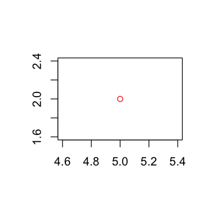

```r
pt = st_point( c(5,2) )
class(pt)
pt
plot(pt,col="red")
box()
axis(1,labels=T)
axis(2,labels=T)
```

### LINESTRING

```r
linestring_matrix = rbind( c(5,2) , c(4,6), c(2,4) )
class( linestring_matrix )
```

'matrix'

1. 'XY'

2. 'LINESTRING'

3. 'sfg'

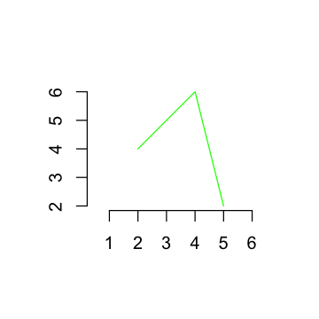

```r
ln = st_linestring( linestring_matrix )
class(ln)
plot(ln,col="green")
axis(1,labels=T)
axis(2,labels=T)
```

### POLYGON

```r
polygon_list = list(rbind( c(2,4), c(4,6), c(5,2) , c(2,4) ))
class( polygon_list )
```

'list'

1. 'XY'

2. 'POLYGON'

3. 'sfg'

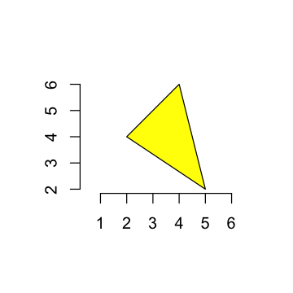

```r
pg = st_polygon( polygon_list )
class(pg)
plot(pg,col="yellow")
axis(1,labels=T)
axis(2,labels=T)
```

### MULTIPOINT

```r
multipoint_matrix = rbind( c(5,2) , c(4,6), c(2,4) )
class( multipoint_matrix )
```

'matrix'

1. 'XY'

2. 'MULTIPOINT'

3. 'sfg'

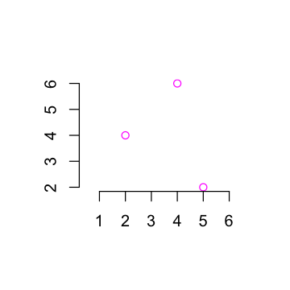

```r
mp = st_multipoint( multipoint_matrix )
class(mp)
plot(mp,col="magenta")
axis(1,labels=T)
axis(2,labels=T)
```

### MULTILINESTRING

1. 'XY'

2. 'MULTILINESTRING'

3. 'sfg'

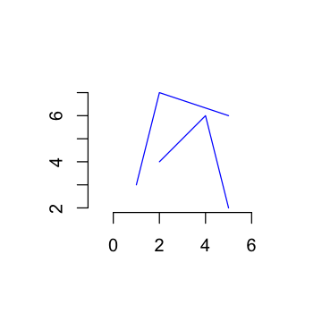

```r
multilinestring_list = list( rbind( c(5,2) , c(4,6) , c(2,4) ) ,
                             rbind( c(1,3) , c(2,7) , c(5,6) )
                           )
mln = st_multilinestring( multilinestring_list )
class(mln)
plot(mln,col="blue")
axis(1,labels=T)
axis(2,labels=T)
```

### MULTIPOLYGON

```r
multipolygon_list = list(list(rbind(c(1, 5), c(2, 2), c(4, 1), c(4, 4), c(1, 5))),
                         list(rbind(c(0, 2), c(1, 2), c(1, 3), c(0, 3), c(0, 2))))
class(multipolygon_list)
```

'list'

1. 'XY'

2. 'MULTIPOLYGON'

3. 'sfg'

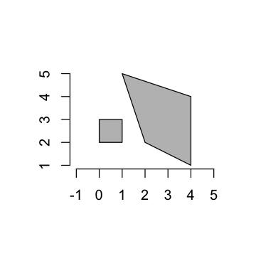

```r
mpg = st_multipolygon( multipolygon_list )
class(mpg)
plot(mpg,col="gray")
axis(1,labels=T)
axis(2,labels=T)
```

### GEOMETRYCOLLECTION

```r
multipoint_matrix = rbind(c(5, 2), c(1, 3), c(3, 4), c(3, 2))
linestring_matrix = rbind(c(1, 5), c(4, 4), c(4, 1), c(2, 2), c(3, 2))
class(multipoint_matrix)
class(linestring_matrix)
```

'matrix'

'matrix'

1. 'XY'

2. 'GEOMETRYCOLLECTION'

3. 'sfg'

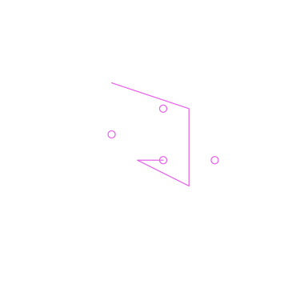

```r
geometrycollection_list = list(st_multipoint(multipoint_matrix),
                              st_linestring(linestring_matrix))
gcoll = st_geometrycollection(gemetrycollection_list)
class(gcoll)
plot(gcoll,col="violet")
```

## Simple features columns (sfc)

### (from geometry to geospatial obj)

One **sfg** object contains only a single simple feature geometry.  
A **simple feature geometry column** (**sfc**) is a list of sfg objects, which is additionally able to contain information about the coordinate reference system in use.

```r
point1 = st_point(c(5, 2))
point2 = st_point(c(1, 3))
points_sfc = st_sfc(point1, point2)
print(points_sfc)
```

```
Geometry set for 2 features
geometry type:  POINT
dimension:      XY
bbox:           xmin: 1 ymin: 2 xmax: 5 ymax: 3
epsg (SRID):    NA
proj4string:    NA
```

```
POINT (5 2)
POINT (1 3)
```

```r
plot(points_sfc)
```

[output not shown]

```r
polygon_list1 = list(rbind(c(1, 5), c(2, 2), c(4, 1), c(4, 4), c(1, 5)))
polygon1 = st_polygon(polygon_list1)
polygon_list2 = list(rbind(c(0, 2), c(1, 2), c(1, 3), c(0, 3), c(0, 2)))
polygon2 = st_polygon(polygon_list2)
polygon_sfc = st_sfc(polygon1, polygon2)
st_geometry_type(polygon_sfc)
```

1. POLYGON

2. POLYGON

**Levels**:**

1. 'GEOMETRY'

2. 'POINT'

3. 'LINESTRING'

4. 'POLYGON'

5. 'MULTIPOINT'

6. 'MULTILINESTRING'

7. 'MULTIPOLYGON'

8. 'GEOMETRYCOLLECTION'

9. 'CIRCULARSTRING'

10. 'COMPOUNDCURVE'

11. 'CURVEPOLYGON'

12. 'MULTICURVE'

13. 'MULTISURFACE'

14. 'CURVE'

15. 'SURFACE'

16. 'POLYHEDRALSURFACE'

17. 'TIN'

18. 'TRIANGLE'

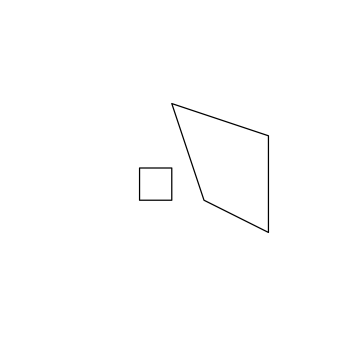

```r
plot(polygon_sfc)
```

#### It is also possible to create an sfc object from sfg objects with different geometry types:

```r
# sfc GEOMETRY
multilinestring_list1 = list(rbind(c(1, 5), c(4, 4), c(4, 1), c(2, 2), c(3, 2)),
                            rbind(c(1, 2), c(2, 4)))
multilinestring1 = st_multilinestring((multilinestring_list1))

point_multilinestring_sfc = st_sfc(point1, multilinestring1)
st_geometry_type(point_multilinestring_sfc)
```

1. POINT

2. MULTILINESTRING

**Levels**:**

1. 'GEOMETRY'

2. 'POINT'

3. 'LINESTRING'

4. 'POLYGON'

5. 'MULTIPOINT'

6. 'MULTILINESTRING'

7. 'MULTIPOLYGON'

8. 'GEOMETRYCOLLECTION'

9. 'CIRCULARSTRING'

10. 'COMPOUNDCURVE'

11. 'CURVEPOLYGON'

12. 'MULTICURVE'

13. 'MULTISURFACE'

14. 'CURVE'

15. 'SURFACE'

16. 'POLYHEDRALSURFACE'

17. 'TIN'

18. 'TRIANGLE'

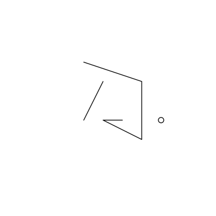

```r
plot(point_multilinestring_sfc)
```

### CRS (Coordinate Reference System)

**sfc** objects can additionally store information on the coordinate reference systems (CRS).  
To specify a certain CRS, we can use the **epsg** (SRID) or **proj4string** attributes of an sfc object.  
The default value of epsg (SRID) and proj4string is **NA** (Not Available), as can be verified with **st_crs( )**:

```r
st_crs(points_sfc)
```

```
Coordinate Reference System: NA
```

```r
# EPSG definition
points_sfc_wgs = st_sfc(point1, point2, crs = 4326)
st_crs(points_sfc_wgs)
```

```
Coordinate Reference System:
  EPSG: 4326
  proj4string: "+proj=longlat +datum=WGS84 +no_defs"
```

```r
# PROJ4STRING definition
st_sfc(point1, point2, crs = "+proj=longlat +datum=WGS84 +no_defs")
```

[output not shown]

```
Geometry set for 2 features
geometry type:  POINT
dimension:      XY
bbox:           xmin: 1 ymin: 2 xmax: 5 ymax: 3
epsg (SRID):    4326
proj4string:    +proj=longlat +datum=WGS84 +no_defs
```

## The sf class

**'sf geometry'** is purely geometric object and **'sf column'** is a geographic building block.  
The final building block is non-geographic attributes representing other attributed such as measured values.  
**st_sf( )**

### Example using Climatic Ground Stations

To illustrate attributes, we will use the temperature and precipitation measured at ground weather stations.

```r
require(readxl)
Tmax <- read_excel("~/work/Didattica/Agraria/GeVS/2019/esercizi/Tmax.xlsx", sheet = "R", na = "NA")
Rain <- read_excel("~/work/Didattica/Agraria/GeVS/2019/esercizi/Rainfall.xlsx", sheet = "R", na = "NA")
```

```r
point   = st_point(c(10.91571, 44.65191))     # sfg object
geom    = st_sfc(point, crs = 4326)           # sfc object
attrib  = data.frame(                         # data.frame object
   name = "MODENAURB",
   date = as.Date(Tmax$GIORNO[1]),
   temperature = Tmax$MODENAURB[1],
   rainfall = Rain$MODENAURB[1]
)
# Simple Feature (Collection):
SF = st_sf(attrib, geometry = geom)          # sf object
```

```r
class(point)
class(geom)
class(SF)
```

1. 'XY'

2. 'POINT'

3. 'sfg'

1. 'sfc_POINT'

2. 'sfc'

1. 'sf'

2. 'data.frame'

```r
print(SF)
```

```
Simple feature collection with 1 feature and 4 fields
geometry type:  POINT
dimension:      XY
bbox:           xmin: 10.91571 ymin: 44.65191 xmax: 10.91571 ymax: 44.65191
epsg (SRID):    4326
proj4string:    +proj=longlat +datum=WGS84 +no_defs
       name       date temperature rainfall                  geometry
1 MODENAURB 2007-01-01         6.5        0 POINT (10.91571 44.65191)
```

```r
names(SF)
```

1. 'name'

2. 'date'

3. 'temperature'

4. 'rainfall'

5. 'geometry'

```r
print(SF$geometry)
```

```
Geometry set for 1 feature
geometry type:  POINT
dimension:      XY
bbox:           xmin: 10.91571 ymin: 44.65191 xmax: 10.91571 ymax: 44.65191
epsg (SRID):    4326
proj4string:    +proj=longlat +datum=WGS84 +no_defs
```

```
POINT (10.91571 44.65191)
```

```r
ER  = osmdata::getbb("Emilia Romagna",format_out="sf_polygon") # => polygon
#ER  = osmdata::getbb("Emilia Romagna") # => square Bounding Box
```

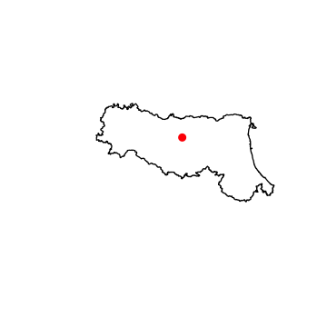

```r
plot(ER$geometry,reset=F)
plot(SF$geometry,add=T,pch=16,col="red")
```

```r
point   = st_point(c(11.1987, 44.48924))        # sfg object
geom    = st_sfc(point, crs = 4326)             # sfc object
attrib  = data.frame(                           # data.frame object
   name = names(Tmax)[4],
   date = as.Date(Tmax$GIORNO[1]),
   temperature = Tmax$ZOLAPREDOSAAGRO[1],
   rainfall = Rain$ZOLAPREDOSAAGRO[1]
)
# Simple Feature Collection:
SF = rbind(SF,st_sf(attrib, geometry = geom)) # sf object
```

```r
print(SF)
```

```
Simple feature collection with 2 features and 4 fields
geometry type:  POINT
dimension:      XY
bbox:           xmin: 10.91571 ymin: 44.48924 xmax: 11.1987 ymax: 44.65191
epsg (SRID):    4326
proj4string:    +proj=longlat +datum=WGS84 +no_defs
             name       date temperature rainfall                  geometry
1       MODENAURB 2007-01-01         6.5        0 POINT (10.91571 44.65191)
2 ZOLAPREDOSAAGRO 2007-01-01         8.4        0  POINT (11.1987 44.48924)
```

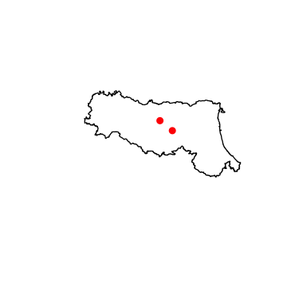

```r
plot(ER$geometry,reset=F)
plot(SF$geometry,add=T,pch=16,col="red")
```

### Example using world data

```r
data(world)
names(world)
```

1. 'iso_a2'

2. 'name_long'

3. 'continent'

4. 'region_un'

5. 'subregion'

6. 'type'

7. 'area_km2'

8. 'pop'

9. 'lifeExp'

10. 'gdpPercap'

11. 'geom'

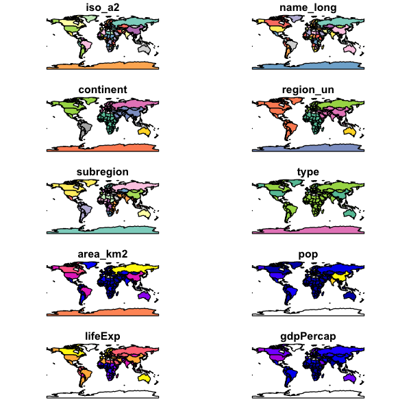

```r
plot(world)
```

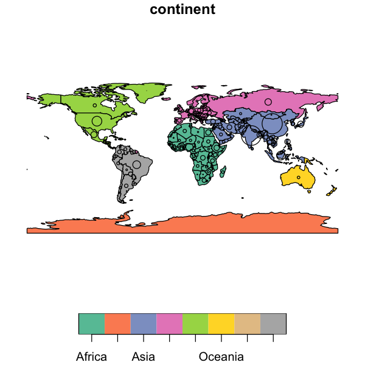

```r
options(warn=-1)
plot(world["continent"], reset = FALSE)
siz = sqrt(world$pop) / 10000
world_cents = st_centroid(world, of_largest_polygon = TRUE)
plot(st_geometry(world_cents), add = TRUE, cex = siz)
```

```r
summary(world["lifeExp"])
```

```
    lifeExp                 geom
 Min.   :50.62   MULTIPOLYGON :177
 1st Qu.:64.96   epsg:4326    :  0
 Median :72.87   +proj=long...:  0
 Mean   :70.85
 3rd Qu.:76.78
 Max.   :83.59
 NA's   :10
```

```r
world_asia = world[world$continent == "Asia", ]
```

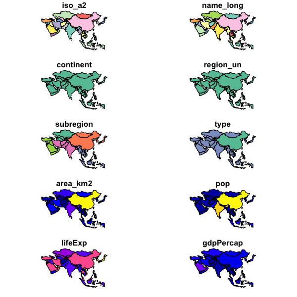

```r
plot(world_asia)
```

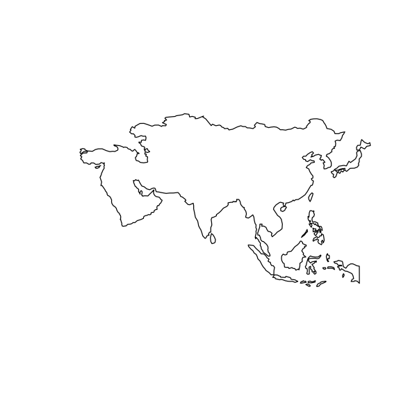

```r
asia = st_union(world_asia)
plot(asia)
```

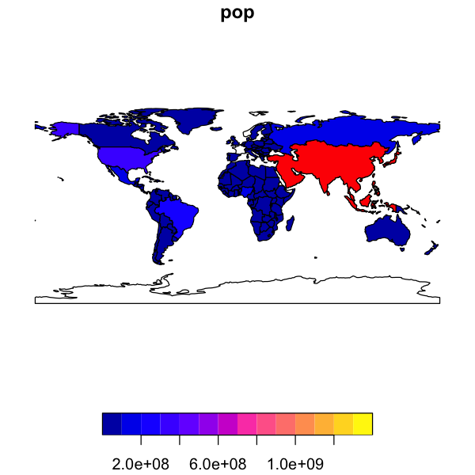

```r
plot(world["pop"], reset = FALSE)
plot(asia, add = TRUE, col = "red")
```

### Example importing shapefile

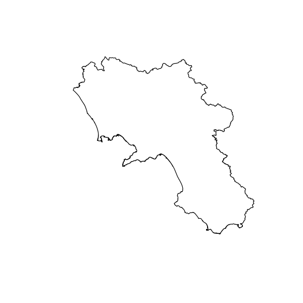

```r
Ca = osmdata::getbb("Campania", format_out = "sf_polygon")
plot(Ca)
```

```r
carta_pedologica_VT = "~/work/Didattica/Agraria/GeVS/2019/esercizi/07_Carta_Pedologica/Carta_pedologica.shp"
VT = st_read( carta_pedologica_VT )
```

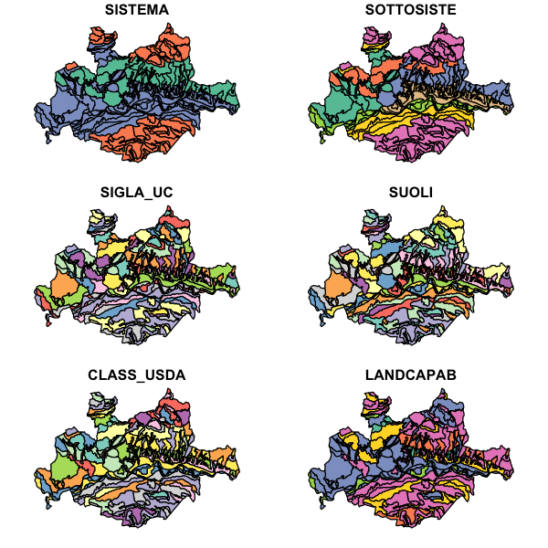

```r
plot(VT)
```

```r
st_crs(Ca)
```

```
Coordinate Reference System:
  EPSG: 4326
  proj4string: "+proj=longlat +datum=WGS84 +no_defs"
```

```r
st_crs(VT)
```

```
Coordinate Reference System:
  EPSG: 32633
  proj4string: "+proj=utm +zone=33 +datum=WGS84 +units=m +no_defs"
```

```r
Ca_proj = st_transform(Ca, 32633)
st_crs(Ca_proj)
```

```
Coordinate Reference System:
  EPSG: 32633
  proj4string: "+proj=utm +zone=33 +datum=WGS84 +units=m +no_defs"
```

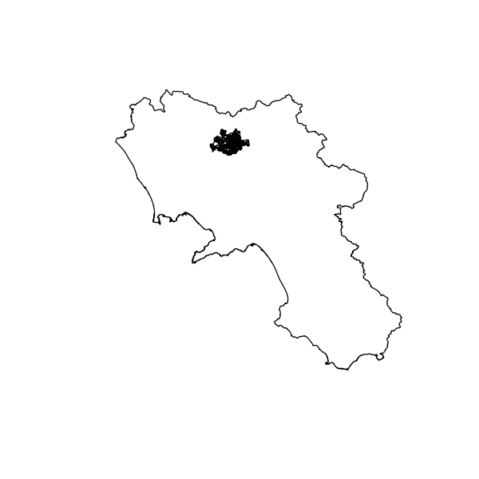

```r
plot(Ca_proj,reset=F)
plot(st_geometry(VT),add=T)
```